# Univariate Regression on Cars data

You can find a version of this document already knit and published on the cloud here: https://rpubs.com/sachinvarriar/cars_regression

#### X - independent variable/feature

#### Y - dependent variable/response

Y=f(X) Y is dependent on the value of X. Think of substituting X in the fn f() to obtain Y

```r
data('cars')
summary(cars)
```

```
     speed           dist
 Min.   : 4.0   Min.   :  2.00
 1st Qu.:12.0   1st Qu.: 26.00
 Median :15.0   Median : 36.00
 Mean   :15.4   Mean   : 42.98
 3rd Qu.:19.0   3rd Qu.: 56.00
 Max.   :25.0   Max.   :120.00
```

lm() stands for linear model. Why linear model? This performs a “linear” regression on the data and gives us the equation of the line that generalizes the relation between Y and X(s)

```r
model<-lm(speed~dist,cars)
```

```r
print(model)
```

```
Call:
lm(formula = speed ~ dist, data = cars)

Coefficients:
(Intercept)         dist
     8.2839       0.1656
```

Y=8.2839 + 0.1656*dist

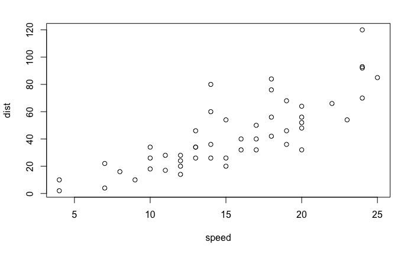

```r
plot(cars)
```

```r
cor(cars)
```

```
          speed      dist
speed 1.0000000 0.8068949
dist  0.8068949 1.0000000
```

```r
summary(model)
```

```
Call:
lm(formula = speed ~ dist, data = cars)

Residuals:
    Min      1Q  Median      3Q     Max
-7.5293 -2.1550  0.3615  2.4377  6.4179

Coefficients:
            Estimate Std. Error t value Pr(>|t|)
(Intercept)  8.28391    0.87438   9.474 1.44e-12 ***
dist         0.16557    0.01749   9.464 1.49e-12 ***
---
Signif. codes:  0 ‘***’ 0.001 ‘**’ 0.01 ‘*’ 0.05 ‘.’ 0.1 ‘ ’ 1

Residual standard error: 3.156 on 48 degrees of freedom
Multiple R-squared:  0.6511,    Adjusted R-squared:  0.6438
F-statistic: 89.57 on 1 and 48 DF,  p-value: 1.49e-12
```

Looking at the model, we observe that the F-statistics p value is 1.49*10^-12 which makes it significant in the 99.99% confidence interval or almost 100% confidence interval. Hence we can reject null hypothesis and assume the model is statistically significant

Also, the p-value for t-test on intercept is 1.44*10^-12, which tells us that it is significant in the 99.99% confidence interval. hence the intercept is statistically significant

Also, the p-value for t-test on coeff of dist is 1.49*10^-12, which tells us that it is significant in the 99.99% confidence interval. hence the coefficient is statistically significant

the goodness of fit of the model here is 0.6511 based on multiple R-sq

The resultant equation is Y=8.2839 + 0.1656*dist